# Predict Quality of Activity

sarigela

Saturday, December 13, 2014

# Abstract

Activity trackers such as Microsoft Band, Nike Fuel, Fit bit and many others are being used to capture lot of activities information. However, correctness or quality of the action is not provided. This project predicts the manner in which exercises are done by classifying them on scale of A to E. The prediction accuracy range for the final model developed is **99.39% - 99.59%**.

# Exploratory Data Analysis

The source of the data set is ‘http://groupware.les.inf.puc-rio.br/har.’ Two sets of data training and testing are downloaded to disc and loaded for anlysis. The outcome variable is factor `classe` with levels `A B C D E`

From looking at the data, though *160* variables are present some of them are either empty or having NA. We have *104* such variables which are being removed from the original training set giving us only *56* variables for prediction.

This trimmed down original training data is split into *3* partitions - `training`, sub-`testing` and `validation`.

# Model fitting and cross-validation

We need to build a model with outcome `classe` based all othe variables as predictors. Based on the data, the *linear regression models* such as lm, glm will not suite. Predicting with *Trees* is needed. The first model was tried with `method ="rpart"` that yeilded a poor accuracy of `52.33%`. Please refer Appendix for dendogram of the classification tree.

**Random Forest** method has been picked as the next alternative and found the accuracy to be `99.4%` with sampling *Cross-validated (5 folds)*. Increased the sampling *Cross-Validation* to `10 fold` to improve the accuracy to `99.5%` with `mtry=30`(model result in `modRF`). Parallel processing library `doSnow` used for high performance.

# Combining predictors

These two models applied over sub-`testing` set to get predictions (`pred1, pred2`). A new combined model `combofit` is generated using results - pred1, pred2 and `testing$classe`.

## Out of Sample error rate in sub testing data set

The results of applying these models over sub-testing data set is computed and are as below:

- The success percentage of the computed predictions for `modRF`, `modTreeBag` and `combofit` are **99.32%, 99.39% and 99.59** respectively.
- **Out of Sample Error** percentage of these three models is **0.68% , 0.61% and 0.41%** respectively.
- From this data it is evident that our **combined model** of `combofit` gives better accuracy on our sub-traning model than other two.

## Out of Sample error rate in *Validation* data Set

The first two models are applied over validation set and predictions are fetched. The `combofit` model is applied on the resultant predictions from `modRF` and `modTreeBag`. The results of this are as follow:

- The success percentage of computed prediction for `modRF`, `modTreeBag` and `combofit` are **99.3%, 99.32% and 99.39%** respectively.
- **Out of Sample Error Rate** of these three models is **0.7%, 0.68% and 0.61%** respectively.

# Conclusion

The combined model `combofit` is the final model that will be used for prediction with accuracy range of **99.39% - 99.59%**. The sample error rate rate is **0.61 - 0.41%** which is very promising.

This model is used on the original test data and the results of the prediction are:

```
##  [1] B A B A A E D B A A B C B A E E A B B B
## Levels: A B C D E
```

**NOTE:** The percentange and figures are computed with actual R code in this report. Please refer the .RMD file to verify the code. Plots and results from the above experiment are presented in Appendix

# Appendix

### Classification Tree Dendrogram

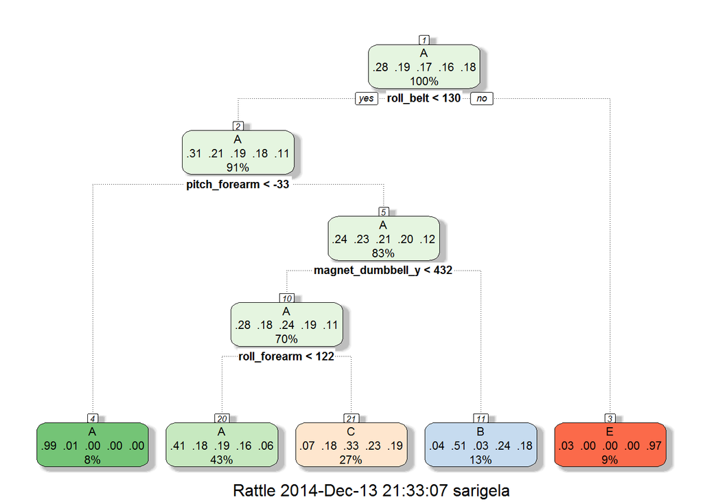

### Random Tree Model Fit.

```
## Random Forest
##
## 9619 samples
##   55 predictor
##    5 classes: 'A', 'B', 'C', 'D', 'E'
##
## No pre-processing
## Resampling: Cross-Validated (10 fold)
##
## Summary of sample sizes: 8658, 8657, 8657, 8658, 8657, 8656, ...
##
## Resampling results across tuning parameters:
##
##   mtry  Accuracy   Kappa      Accuracy SD  Kappa SD
##    2    0.9904359  0.9879000  0.002890780  0.003657398
##   30    0.9948018  0.9934245  0.003061112  0.003871681
##   59    0.9924116  0.9904010  0.003500065  0.004427188
##
## Accuracy was used to select the optimal model using  the largest value.
## The final value used for the model was mtry = 30.
```

### Tree Bag Model Fit

```
## Bagged CART
##
## 9619 samples
##   55 predictor
##    5 classes: 'A', 'B', 'C', 'D', 'E'
##
## No pre-processing
## Resampling: Cross-Validated (5 fold)
##
## Summary of sample sizes: 7694, 7695, 7696, 7695, 7696
##
## Resampling results
##
##   Accuracy   Kappa      Accuracy SD  Kappa SD
##   0.9888759  0.9859255  0.003281355  0.004153007
##
##
```

### Plot comparing the two model fits

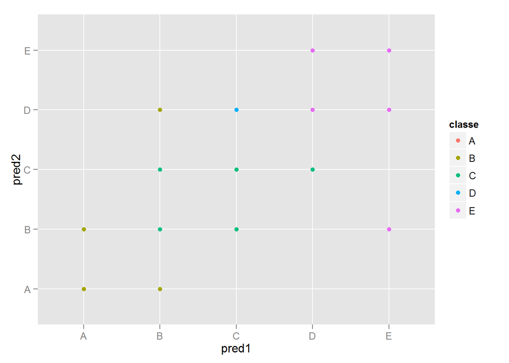

### Final Combined Predictors model fit

```
## Random Forest
##
## 4118 samples
##    2 predictor
##    5 classes: 'A', 'B', 'C', 'D', 'E'
##
## No pre-processing
## Resampling: Bootstrapped (25 reps)
##
## Summary of sample sizes: 4118, 4118, 4118, 4118, 4118, 4118, ...
##
## Resampling results across tuning parameters:
##
##   mtry  Accuracy   Kappa      Accuracy SD  Kappa SD
##   2     0.9947572  0.9933631  0.001398395  0.001770910
##   5     0.9946776  0.9932619  0.001571641  0.001991607
##   8     0.9946535  0.9932317  0.001431800  0.001813230
##
## Accuracy was used to select the optimal model using  the largest value.
## The final value used for the model was mtry = 2.
```